```python
#Setup
import pandas as pd
import numpy as np
import seaborn as sns
import warnings as wr
import matplotlib.pyplot as plt

from sklearn.linear_model import LinearRegression
from sklearn.metrics import mean_squared_error, r2_score
from sklearn.model_selection import train_test_split

wr.filterwarnings('ignore')
```

# Caso Ventas de Helado

```python
#Acá puede capturar cualquier dataframe
df = pd.DataFrame({
    'Temperatura': [20, 27, 33, 29, 21, 34, 30],
    'Horas_sol': [4, 6, 9, 5, 2, 7, 6],
    'Ventas': [10, 13, 19, 12, 7, 17, 15]
})

print(df)
```

```
   Temperatura  Horas_sol  Ventas
0           20          4      10
1           27          6      13
2           33          9      19
3           29          5      12
4           21          2       7
5           34          7      17
6           30          6      15
```

1. ¿Cuál es el coeficiente de correlación entre la temperatura y las ventas?

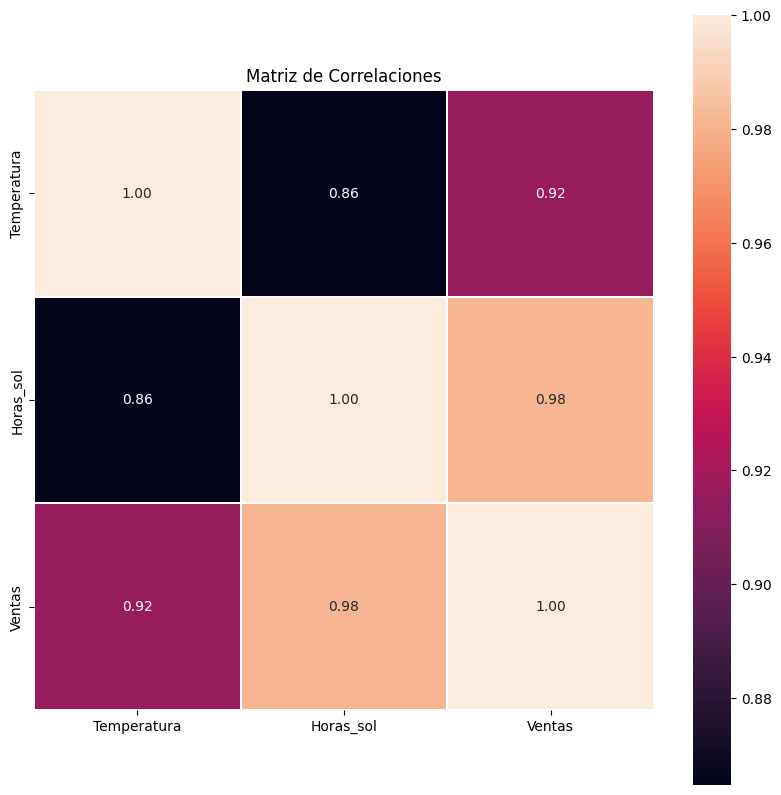

```
La correlación entre las ventas y la temperatura es de 0.9159929126680687, lo cual es una relación positiva y fuerte
```

```python
import matplotlib.pyplot as plt

plt.figure(figsize=(10, 10))
sns.heatmap(df.corr(), annot=True, fmt=".2f", linewidths=.2, square=True)
plt.title("Matriz de Correlaciones")
plt.show()

print(f"La correlación entre las ventas y la temperatura es de {df['Temperatura'].corr(df['Ventas'])}, lo cual es una relación positiva y fuerte")
```

2. ¿Cuánto aumentan las ventas (en miles) por cada hora de sol manteniendo la temperatura constante?

```python
# Preparación de los datos
X = df[['Temperatura', 'Horas_sol']]
y = df['Ventas']

# Ajuste del modelo de regresión lineal
model = LinearRegression().fit(X, y)

# Coeficientes separados o Thetas
coef_temp, coef_horas_sol = model.coef_
print(f"Coeficiente de temperatura: {coef_temp}")
print(f"Coeficiente de horas de sol: {coef_horas_sol}\n")

print(f"Se aumenta en {coef_horas_sol:.2f} helados por hora de sol agregada")
```

```
Coeficiente de temperatura: 0.20165745856353628
Coeficiente de horas de sol: 1.383977900552486

Se aumenta en 1.38 helados por hora de sol agregada
```

# Caso Redes Sociales:

```python
df2 = pd.DataFrame({
    "Facebook": [2, 4, 6, 8, 10, 12, 14],
    "Instagram": [1, 2, 4, 3, 5, 6, 7],
    "Ventas": [5, 9, 15, 17, 21, 24, 28]
})

print(df2)
```

```
   Facebook  Instagram  Ventas
0         2          1       5
1         4          2       9
2         6          4      15
3         8          3      17
4        10          5      21
5        12          6      24
6        14          7      28
```

3. ¿Cuánto contribuye el presupuesto de Facebook a las ventas, manteniendo el presupuesto de Instagram constante?

```python
# Preparación de los datos
X = df2[['Facebook', 'Instagram']]
y = df2['Ventas']

# Ajuste del modelo de regresión lineal
model = LinearRegression().fit(X, y)

# Coeficientes separados o Thetas
coef_facebook, coef_instagram = model.coef_
print(f"Coeficiente de presupuesto facebook: {coef_facebook}")
print(f"Coeficiente de presupuesto instagram: {coef_instagram}\n")

print(f"El presupuesto de Facebook contribuye aproximadamente {coef_facebook:.2f} unidades a las ventas por cada incremento de una unidad en el presupuesto de Facebook")
```

```
Coeficiente de presupuesto facebook: 1.4454545454545447
Coeficiente de presupuesto instagram: 0.8909090909090899

El presupuesto de Facebook contribuye aproximadamente 1.45 unidades a las ventas por cada incremento de una unidad en el presupuesto de Facebook
```

4. ¿Cuántos miles se espera ganar si se invierten 2 mil en Instagram y en 2 mil en Facebook?

```python
registro_1 = [2, 2]
prediccion_1 = model.predict([registro_1])
print(f"Se predice que si se invierten 2000 en Facebook y 2000 en Instragram se esperan ganar aproximadamente: {(prediccion_1[0] * 1000):.2f} ")
```

```
Se predice que si se invierten 2000 en Facebook y 2000 en Instragram se esperan ganar aproximadamente: 6545.45
```

5. ¿Cuál es el ECM en la regresión lineal múltiple usando todos los datos?

```python
# Calcula las predicciones
y_pred = model.predict(X)

# Calcula métricas de evaluación
mse = mean_squared_error(y, y_pred)
r2 = model.score(X, y)

print(f"MSE: {mse}")
```

```
MSE: 0.38441558441558393
```

6. Con respecto al modelo obtenido con todos los datos ¿qué se podría decir del R2?

```python
print(f"El valor de R^2 es aproximadamente de: {r2:.2f}\n")

print(f"Esto indica que el modelo explica un {(r2 * 100):.2f} % de la variabilidad de las ventas. El modelo se ajusta muy bien a los datos")
```

```
El valor de R^2 es aproximadamente de: 0.99

Esto indica que el modelo explica un 99.32 % de la variabilidad de las ventas. El modelo se ajusta muy bien a los datos
```

# Caso Calificación de Vinos:

```python
df_vinos = pd.DataFrame({
    "Acidez": [7, 8.1, 6.2, 7.2, 7.4, 6.5, 7.8, 6.9, 7.6],
    "Azucar": [1.8, 2.6, 2.3, 2.8, 2.9, 2.1, 2.7, 2.4, 2.5],
    "Calidad": [5, 7, 4, 6, 5, 6, 7, 5, 6]
})


# Mostrar el DataFrame
df_vinos

# Preparación de los datos
X = df_vinos[['Acidez', 'Azucar']]
y = df_vinos['Calidad']
```

7. ¿Cuál es el impacto en la 'Calidad' por cada unidad incrementada en 'Acidez'?

```python
# Ajuste del modelo de regresión lineal
model = LinearRegression().fit(X, y)

# Coeficientes separados o Thetas
coef_acidez, coef_azucar = model.coef_
print(f"Coeficiente de acidez: {coef_temp}")
print(f"Coeficiente de azucar: {coef_horas_sol}\n")

print(f"Se aumenta en {coef_acidez:.2f} unidades la calidad por cada unidad de aumento en la acidez")
```

[output not shown]

8. ¿Cuánto es el R2 para la regresión lineal múltiple en este caso?

```python
# Calcula las predicciones
y_pred = model.predict(X)

r2 = model.score(X, y)

print(f"R^2: {r2}")
```

```
R^2: 0.6015306507624936
```

9. Si realizamos una predicción con el primer registro: 7 de acidez y 1.8 de azúcar ¿Cuánto varía el valor predicho con el modelo (creado por todos los datos) con respecto al valor real?

```python
model2 = model.predict([[7, 1.8]])
print(f"Predicción para el registro 1: {model2[0]}")

# Calcular variación
variacion = abs(model2[0] - df_vinos.iloc[0]['Calidad'])

print(f"Variación: {variacion}\n")


print(f"El valor predicho con el modelo es {model2[0]:.2f}, mientras que el valor real es 5. La variación entre el valor predicho y el real es aproximadamente {variacion:.2f} puntos.")
```

```
Predicción para el registro 1: 5.612335799486638
Variación: 0.6123357994866376

El valor predicho con el modelo es 5.61, mientras que el valor real es 5. La variación entre el valor predicho y el real es aproximadamente 0.61 puntos.
```

# Caso Predicción del precio de Casas:

```python
# Crear el DataFrame con los datos proporcionados
df_casas = pd.DataFrame({
    "Tamaño": [120, 80, 150, 100, 200, 90, 160, 110],
    "Habitaciones": [3, 2, 4, 3, 5, 2, 4, 3],
    "Edad": [5, 10, 2, 20, 1, 15, 10, 7],
    "DistanciaMetro": [500, 1500, 250, 1000, 100, 2000, 300, 700],
    "Jardín": [1, 0, 1, 0, 1, 0, 1, 0],
    "Precio": [300, 200, 450, 250, 600, 220, 400, 280]
})

# Mostrar el DataFrame
df_casas

# Preparación de los datos
X = df_casas[['Tamaño', 'Habitaciones', 'Edad', 'DistanciaMetro', 'Jardín']]
y = df_casas['Precio']

# Ajuste del modelo de regresión lineal
model = LinearRegression().fit(X, y)
```

```python
prediccion = model.predict([[130, 3, 8, 400, 1]])
print(f"Precio esperado: {prediccion[0]}")
```

```
Precio esperado: 257.7237085607552
```

11.¿Cuánto aumenta el precio de una casa por tener jardín?

```python
# Coeficientes separados o Thetas
coef_tam, coef_hab, coef_edad, coef_dismetro, coef_jardin = model.coef_

coef_jardin
print(f"Coeficiente de jardín: {coef_jardin}")

print(f"Se aumenta en {coef_jardin:.2f} unidades el precio por tener jardín")
```

```
Coeficiente de jardín: 34.98562523824837
Se aumenta en 34.99 unidades el precio por tener jardín
```

12.¿Cuál es el impacto en el precio de una casa por cada año de Edad que pasa sin venderse?

```python
coef_edad
print(f"Coeficiente de edad: {coef_edad}")

print(f"Se aumenta en {coef_edad:.2f} unidades el precio por cada año de edad que pasa sin venderse")
```

```
Coeficiente de edad: -6.25022094541079
Se aumenta en -6.25 unidades el precio por cada año de edad que pasa sin venderse
```

13.¿Qué variable es más importante a la hora de calcular el precio de una casa?

```python
importance = pd.DataFrame({'Variable': X.columns, 'Importance': abs(model.coef_)})
importance = importance.sort_values(by='Importance', ascending=False)
print(importance)
print(f"\nLa variable más importante para calcular el precio de una casa es: {importance['Variable'].iloc[0]}")
```

```
         Variable  Importance
1    Habitaciones  193.219393
4          Jardín   34.985625
2            Edad    6.250221
0          Tamaño    0.756369
3  DistanciaMetro    0.129055

La variable más importante para calcular el precio de una casa es: Habitaciones
```

```python
# Datos de la casa original
tamano_original = 50
habitaciones_original = 2
edad_original = 10
distancia_metro_original = 400
jardin_original = 1

# Datos de la casa ampliada
tamano_ampliado = tamano_original + 25  # Ampliación de 25 m2
habitaciones_ampliado = habitaciones_original + 1  # Nueva habitación

# Predicción del precio original
precio_original = model.predict([[tamano_original, habitaciones_original, edad_original, distancia_metro_original, jardin_original]])

# Predicción del precio ampliado
precio_ampliado = model.predict([[tamano_ampliado, habitaciones_ampliado, edad_original, distancia_metro_original, jardin_original]])

# Diferencia de precio
diferencia_precio = precio_ampliado[0] - precio_original[0]

print(f"El precio original de la casa es: {precio_original[0]:.2f}")
print(f"El precio de la casa ampliada es: {precio_ampliado[0]:.2f}")
print(f"El impacto de la ampliación en el valor es un aumento de: {diferencia_precio:.2f}")
```

```
El precio original de la casa es: 112.51
El precio de la casa ampliada es: 286.82
El impacto de la ampliación en el valor es un aumento de: 174.31
```

```python
%%shell
jupyter nbconvert --to html /content/Taller1AnalisisDatos.ipynb
```

[output not shown]